# Multi-Class Image Classification Deep Learning Model for Cassava Leaf Disease Using TensorFlow Take 3

### March 11, 2021

Template Credit: Adapted from a template made available by Dr. Jason Brownlee of Machine Learning Mastery. [https://machinelearningmastery.com/]

SUMMARY: This project aims to construct a predictive model using a TensorFlow convolutional neural network (CNN) and document the end-to-end steps using a template. The Cassava Leaf Disease dataset is a multi-class classification situation where we attempt to predict one of several (more than two) possible outcomes.

INTRODUCTION: As the second-largest provider of carbohydrates in Africa, cassava is an essential food security crop grown by smallholder farmers because it can withstand harsh conditions. Existing disease detection methods require farmers to solicit government-funded agricultural experts' help to visually inspect and diagnose the plants. This method suffers from being labor-intensive, low-supply, and costly.

From iteration Take1, we constructed a CNN model using the InceptionV3 architecture and tested the model's performance using cross-validation. Also, we submitted our model to Kaggle and tested the model's performance using Kaggle's test images.

From iteration Take2, we constructed a CNN model using the ResNet50V2 architecture and tested the model's performance using cross-validation. Also, we submitted our model to Kaggle and tested the model's performance using Kaggle's test images.

In this Take3 iteration, we will construct a CNN model using the DenseNet201 architecture and test the model's performance using cross-validation. Also, we will submit our model to Kaggle and test the model's performance using Kaggle's test images.

ANALYSIS: From iteration Take1, the model's performance achieved an average accuracy score of 67.17% on the validation dataset after 30 epochs. Furthermore, the final model processed Kaggle's test dataset with an accuracy measurement of 61.25%.

From iteration Take2, the model's performance achieved an average accuracy score of 61.86% on the validation dataset after 30 epochs. Furthermore, the final model processed Kaggle's test dataset with an accuracy measurement of 61.28%.

In this Take3 iteration, the model's performance achieved an average accuracy score of 69.50% on the validation dataset after 30 epochs. Furthermore, the final model processed Kaggle's test dataset with an accuracy measurement of 61.30%.

CONCLUSION: In this iteration, the DenseNet201 TensorFlow CNN model appeared to be suitable for modeling this dataset. We should consider experimenting with TensorFlow for further modeling.

Dataset Used: Cassava Leaf Disease Classification

Dataset ML Model: Multi-class image classification with numerical attributes

Dataset Reference: https://www.kaggle.com/c/cassava-leaf-disease-classification/

One potential source of performance benchmarks: https://www.kaggle.com/c/cassava-leaf-disease-classification/leaderboard

A deep-learning image classification project generally can be broken down into five major tasks:

1. Prepare Environment
2. Load and Prepare Images
3. Define and Train Models
4. Evaluate and Optimize Models
5. Finalize Model and Make Predictions

# Task 1 - Prepare Environment

```python
# Install the packages to support accessing environment variable and SQL databases
# !pip install python-dotenv PyMySQL boto3
```

```python
# Retrieve GPU configuration information from Colab
gpu_info = !nvidia-smi
gpu_info = '\n'.join(gpu_info)
if gpu_info.find('failed') >= 0:
    print('Select the Runtime → "Change runtime type" menu to enable a GPU accelerator, ')
    print('and then re-execute this cell.')
else:
    print(gpu_info)
```

```
Sun Mar  7 20:08:38 2021
+-----------------------------------------------------------------------------+
| NVIDIA-SMI 460.39       Driver Version: 460.32.03    CUDA Version: 11.2     |
|-------------------------------+----------------------+----------------------+
| GPU  Name        Persistence-M| Bus-Id        Disp.A | Volatile Uncorr. ECC |
| Fan  Temp  Perf  Pwr:Usage/Cap|         Memory-Usage | GPU-Util  Compute M. |
|                               |                      |               MIG M. |
|===============================+======================+======================|
|   0  Tesla V100-SXM2...  Off  | 00000000:00:04.0 Off |                    0 |
| N/A   39C    P0    24W / 300W |      0MiB / 16160MiB |      0%      Default |
|                               |                      |                  N/A |
+-------------------------------+----------------------+----------------------+

+-----------------------------------------------------------------------------+
| Processes:                                                                  |
|  GPU   GI   CI        PID   Type   Process name                  GPU Memory |
|        ID   ID                                                   Usage      |
|=============================================================================|
|  No running processes found                                                 |
+-----------------------------------------------------------------------------+
```

```python
# Retrieve memory configuration information from Colab
from psutil import virtual_memory
ram_gb = virtual_memory().total / 1e9
print('Your runtime has {:.1f} gigabytes of available RAM\n'.format(ram_gb))

if ram_gb < 20:
    print('To enable a high-RAM runtime, select the Runtime → "Change runtime type"')
    print('menu, and then select High-RAM in the Runtime shape dropdown. Then, ')
    print('re-execute this cell.')
else:
    print('You are using a high-RAM runtime!')
```

```
Your runtime has 13.7 gigabytes of available RAM

To enable a high-RAM runtime, select the Runtime → "Change runtime type"
menu, and then select High-RAM in the Runtime shape dropdown. Then,
re-execute this cell.
```

```python
# Retrieve CPU information from the system
ncpu = !nproc
print("The number of available CPUs is:", ncpu[0])
```

```
The number of available CPUs is: 2
```

## 1.a) Load libraries and modules

```python
# Set the random seed number for reproducible results
seedNum = 888
```

```python
# Load libraries and packages
import random
random.seed(seedNum)
import numpy as np
np.random.seed(seedNum)
import pandas as pd
import matplotlib.pyplot as plt
import matplotlib.image as mpimg
import os
import sys
import zipfile
from datetime import datetime
# import boto3
# from dotenv import load_dotenv
from sklearn.metrics import accuracy_score
from sklearn.metrics import confusion_matrix
from sklearn.metrics import classification_report
import tensorflow as tf
tf.random.set_seed(seedNum)
from tensorflow import keras
from tensorflow.keras.preprocessing.image import ImageDataGenerator
from tensorflow.keras.callbacks import ReduceLROnPlateau
```

## 1.b) Set up the controlling parameters and functions

```python
# Begin the timer for the script processing
startTimeScript = datetime.now()

# Set up the number of CPU cores available for multi-thread processing
n_jobs = 1

# Set up the flag to stop sending progress emails (setting to True will send status emails!)
notifyStatus = False

# Set Pandas options
pd.set_option("display.max_rows", None)
pd.set_option("display.max_columns", None)
pd.set_option("display.width", 140)

# Set the percentage sizes for splitting the dataset
TEST_SET_SIZE = 0.2
VAL_SET_SIZE = 0.2

# Set various default modeling parameters
DEFAULT_LOSS = 'categorical_crossentropy'
DEFAULT_METRICS = ['accuracy']
DEFAULT_OPTIMIZER = tf.keras.optimizers.SGD(learning_rate=0.001)
MAX_EPOCH = 30
BATCH_SIZE = 32
RAW_IMAGE_SIZE = (800, 600)
TARGET_IMAGE_SIZE = (299, 299)
INPUT_IMAGE_SHAPE = (TARGET_IMAGE_SIZE[0], TARGET_IMAGE_SIZE[1], 3)

NUM_CLASSES = 5
CLASS_LABELS = ['0', '1', '2', '3', '4']
CLASS_NAMES = ['Cassava Bacterial Blight (CBB)',
               'Cassava Brown Streak Disease (CBSD)',
               'Cassava Green Mottle (CGM)',
               'Cassava Mosaic Disease (CMD)',
               'Healthy']

# Define the labels to use for graphing the data
train_metric = "accuracy"
validation_metric = "val_accuracy"
train_loss = "loss"
validation_loss = "val_loss"

# Define the directory locations and file names
TRAIN_SUBSET_CSV = 'train.csv'
# TEST_SUBSET_CSV = 'test.csv'
SAMPLE_SUBMISSION_CSV = 'sample_submission.csv'
FINAL_SUBMISSION_CSV = 'submission.csv'
TRAIN_DIR = 'staging/train_images/'
TEST_DIR = 'staging/test_images/'
LABELS_DIR = 'staging/'
OUTPUT_DIR = 'staging/'

# Check the number of GPUs accessible through TensorFlow
print('Num GPUs Available:', len(tf.config.list_physical_devices('GPU')))

# Print out the TensorFlow version for confirmation
print('TensorFlow version:', tf.__version__)
```

```
Num GPUs Available: 1
TensorFlow version: 2.4.1
```

```python
# Set up the parent directory location for loading the dotenv files
# Mount Google Drive locally for storing files
# from google.colab import drive
# drive.mount('/content/gdrive')
# gdrivePrefix = '/content/gdrive/My Drive/Colab_Downloads/'
# env_path = '/content/gdrive/My Drive/Colab Notebooks/'
# dotenv_path = env_path + "python_script.env"
# load_dotenv(dotenv_path=dotenv_path)

# Set up the dotenv file for retrieving environment variables
# env_path = "/Users/david/PycharmProjects/"
# dotenv_path = env_path + "python_script.env"
# load_dotenv(dotenv_path=dotenv_path)
```

```python
# Set up the email notification function
def status_notify(msg_text):
    access_key = os.environ.get('SNS_ACCESS_KEY')
    secret_key = os.environ.get('SNS_SECRET_KEY')
    aws_region = os.environ.get('SNS_AWS_REGION')
    topic_arn = os.environ.get('SNS_TOPIC_ARN')
    if (access_key is None) or (secret_key is None) or (aws_region is None):
        sys.exit("Incomplete notification setup info. Script Processing Aborted!!!")
    sns = boto3.client('sns', aws_access_key_id=access_key, aws_secret_access_key=secret_key, region_name=aws_region)
    response = sns.publish(TopicArn=topic_arn, Message=msg_text)
    if response['ResponseMetadata']['HTTPStatusCode'] != 200 :
        print('Status notification not OK with HTTP status code:', response['ResponseMetadata']['HTTPStatusCode'])
```

```python
if notifyStatus: status_notify('(TensorFlow Multi-Class) Task 1 - Prepare Environment has begun on ' + datetime.now().strftime('%A %B %d, %Y %I:%M:%S %p'))
```

```python
# Reset the random number generators
def reset_random(x):
    random.seed(x)
    np.random.seed(x)
    tf.random.set_seed(x)
```

```python
if notifyStatus: status_notify('(TensorFlow Multi-Class) Task 1 - Prepare Environment completed on ' + datetime.now().strftime('%A %B %d, %Y %I:%M:%S %p'))
```

# Task 2 - Load and Prepare Images

```python
if notifyStatus: status_notify('(TensorFlow Multi-Class) Task 2 - Load and Prepare Images has begun on ' + datetime.now().strftime('%A %B %d, %Y %I:%M:%S %p'))
```

```python
# Clean up the old files and download directories before receiving new ones
!rm -rf staging/
!rm cassava-leaf-disease-classification.zip
```

```
rm: cannot remove 'cassava-leaf-disease-classification.zip': No such file or directory
```

```python
!wget https://dainesanalytics.com/datasets/kaggle-cassava-leaf-disease/cassava-leaf-disease-classification.zip
```

```
--2021-03-07 20:08:42--  https://dainesanalytics.com/datasets/kaggle-cassava-leaf-disease/cassava-leaf-disease-classification.zip
Resolving dainesanalytics.com (dainesanalytics.com)... 13.35.34.122, 13.35.34.74, 13.35.34.67, ...
Connecting to dainesanalytics.com (dainesanalytics.com)|13.35.34.122|:443... connected.
HTTP request sent, awaiting response... 200 OK
Length: 6185662420 (5.8G) [application/zip]
Saving to: ‘cassava-leaf-disease-classification.zip’

cassava-leaf-diseas 100%[===================>]   5.76G  25.7MB/s    in 3m 50s

2021-03-07 20:12:32 (25.7 MB/s) - ‘cassava-leaf-disease-classification.zip’ saved [6185662420/6185662420]
```

```python
STAGING_DIR = 'staging/'
!mkdir staging/
```

```python
# Unzip and put the files into the staging folder
local_zip = 'cassava-leaf-disease-classification.zip'
zip_ref = zipfile.ZipFile(local_zip, 'r')
zip_ref.extractall(STAGING_DIR)
zip_ref.close()
```

```python
train_dataframe = pd.read_csv(LABELS_DIR + TRAIN_SUBSET_CSV)
train_dataframe['label'] = train_dataframe['label'].astype(str)
print(train_dataframe.head())
```

```
         image_id label
0  1000015157.jpg     0
1  1000201771.jpg     3
2   100042118.jpg     1
3  1000723321.jpg     1
4  1000812911.jpg     3
```

```python
# Brief listing of training image files for each class
for c_label in CLASS_LABELS:
    training_class_files = train_dataframe[train_dataframe['label']==c_label]
    print('Number of training images for', CLASS_NAMES[int(c_label)], ':', len(training_class_files))
    print('Training image samples:\n', training_class_files[:5], '\n')
```

```
Number of training images for Cassava Bacterial Blight (CBB) : 1087
Training image samples:
            image_id label
0    1000015157.jpg     0
7    1001320321.jpg     0
18   1003888281.jpg     0
73   1012426959.jpg     0
109  1018973237.jpg     0

Number of training images for Cassava Brown Streak Disease (CBSD) : 2189
Training image samples:
           image_id label
2    100042118.jpg     1
3   1000723321.jpg     1
12  1002088496.jpg     1
22  1004389140.jpg     1
41  1008142548.jpg     1

Number of training images for Cassava Green Mottle (CGM) : 2386
Training image samples:
           image_id label
6   1000910826.jpg     2
15  1003218714.jpg     2
24   100472565.jpg     2
25  1004826518.jpg     2
28  1005200906.jpg     2

Number of training images for Cassava Mosaic Disease (CMD) : 13158
Training image samples:
           image_id label
1   1000201771.jpg     3
4   1000812911.jpg     3
5   1000837476.jpg     3
9   1001742395.jpg     3
10  1001749118.jpg     3

Number of training images for Healthy : 2577
Training image samples:
           image_id label
8   1001723730.jpg     4
17  1003442061.jpg     4
30   100560400.jpg     4
47  1009126931.jpg     4
62  1010806468.jpg     4
```

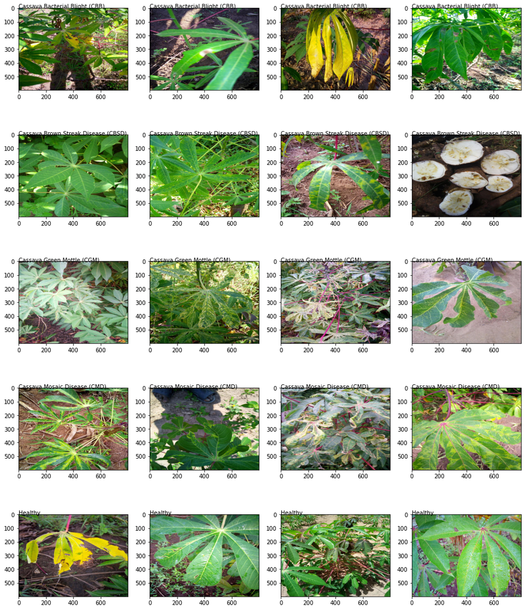

```python
# Plot some training images from the dataset
nrows = 5
ncols = 4
training_examples = []
example_labels = []

fig = plt.gcf()
fig.set_size_inches(ncols * 4, nrows * 4)

for c_label in CLASS_LABELS:
    training_class_files = train_dataframe[train_dataframe['label']==c_label]
    for j in range(ncols):
        training_examples.append(training_class_files.at[training_class_files.index[j],'image_id'])
        example_labels.append(CLASS_NAMES[int(c_label)])
    # print(training_examples)
    # print(example_labels)

for i, img_path in enumerate(training_examples):
    # Set up subplot; subplot indices start at 1
    sp = plt.subplot(nrows, ncols, i+1)
    sp.text(0, 0, example_labels[i])
    # sp.axis('Off')
    img = mpimg.imread(TRAIN_DIR + img_path)
    plt.imshow(img)
plt.show()
```

```python
datagen_kwargs = dict(rescale=1./255, validation_split=VAL_SET_SIZE)
training_datagen = ImageDataGenerator(**datagen_kwargs)
validation_datagen = ImageDataGenerator(**datagen_kwargs)
dataflow_kwargs = dict(batch_size=BATCH_SIZE, class_mode='categorical')

do_data_augmentation = False
if do_data_augmentation:
    training_datagen = ImageDataGenerator(fill_mode="constant",
                                          shear_range=0.2,
                                          zoom_range=(0.5, 1),
                                          horizontal_flip=True,
                                          vertical_flip=True,
                                          rotation_range=360,
                                          width_shift_range=0.2,
                                          height_shift_range=0.2,
                                          brightness_range=(0.75, 1.25),
                                          **datagen_kwargs)

print('Loading and pre-processing the training images...')
training_generator = training_datagen.flow_from_dataframe(train_dataframe,
                                                          directory=TRAIN_DIR,
                                                          x_col='image_id',
                                                          y_col='label',
                                                          target_size=TARGET_IMAGE_SIZE,
                                                          subset='training',
                                                          shuffle=False,
                                                          seed=seedNum,
                                                          **dataflow_kwargs)
print('Number of image batches per epoch of modeling:', len(training_generator))

print('Loading and pre-processing the validation images...')
validation_generator = validation_datagen.flow_from_dataframe(train_dataframe,
                                                              directory=TRAIN_DIR,
                                                              x_col='image_id',
                                                              y_col='label',
                                                              target_size=TARGET_IMAGE_SIZE,
                                                              subset='validation',
                                                              shuffle=False,
                                                              **dataflow_kwargs)
print('Number of image batches per epoch of modeling:', len(validation_generator))
```

```
Loading and pre-processing the training images...
Found 17118 validated image filenames belonging to 5 classes.
Number of image batches per epoch of modeling: 535
Loading and pre-processing the validation images...
Found 4279 validated image filenames belonging to 5 classes.
Number of image batches per epoch of modeling: 134
```

```python
if notifyStatus: status_notify('(TensorFlow Multi-Class) Task 2 - Load and Prepare Images completed on ' + datetime.now().strftime('%A %B %d, %Y %I:%M:%S %p'))
```

# Task 3 - Define and Train Models

```python
if notifyStatus: status_notify('(TensorFlow Multi-Class) Task 3 - Define and Train Models has begun on ' + datetime.now().strftime('%A %B %d, %Y %I:%M:%S %p'))
```

```python
# Define the function for plotting training results for comparison
def plot_metrics(history):
    fig, axs = plt.subplots(1, 2, figsize=(24, 15))
    metrics =  [train_loss, train_metric]
    for n, metric in enumerate(metrics):
        name = metric.replace("_"," ").capitalize()
        plt.subplot(2,2,n+1)
        plt.plot(history.epoch, history.history[metric], color='blue', label='Train')
        plt.plot(history.epoch, history.history['val_'+metric], color='red', linestyle="--", label='Val')
        plt.xlabel('Epoch')
        plt.ylabel(name)
#         if metric == train_loss:
#             plt.ylim([0, plt.ylim()[1]])
#         else:
#             plt.ylim([0.5, 1.1])
        plt.legend()
```

```python
# Define the baseline model for benchmarking
def create_nn_model(input_param=INPUT_IMAGE_SHAPE, output_param=NUM_CLASSES, loss_param=DEFAULT_LOSS, opt_param=DEFAULT_OPTIMIZER, metrics_param=DEFAULT_METRICS):
    nn_model = keras.applications.DenseNet201(include_top=True, weights=None, input_shape=input_param, classes=output_param)
    nn_model.compile(loss=loss_param, optimizer=opt_param, metrics=metrics_param)
    return nn_model
```

```python
# Initialize the neural network model and get the training results for plotting graph
startTimeModule = datetime.now()
learning_rate_reduction = ReduceLROnPlateau(monitor='val_accuracy', patience = 2, verbose=1, factor=0.5, min_lr=0.000001)
reset_random(seedNum)
nn_model_0 = create_nn_model()
nn_model_history = nn_model_0.fit(
    training_generator,
	validation_data=validation_generator,
    epochs=MAX_EPOCH,
    callbacks=[learning_rate_reduction],
    verbose=1)
print('Total time for model fitting:', (datetime.now() - startTimeModule))
```

```
Epoch 00004: ReduceLROnPlateau reducing learning rate to 0.0005000000237487257.

Epoch 00010: ReduceLROnPlateau reducing learning rate to 0.0002500000118743628.

Epoch 00012: ReduceLROnPlateau reducing learning rate to 0.0001250000059371814.

Epoch 00015: ReduceLROnPlateau reducing learning rate to 6.25000029685907e-05.

Epoch 00018: ReduceLROnPlateau reducing learning rate to 3.125000148429535e-05.

Epoch 00020: ReduceLROnPlateau reducing learning rate to 1.5625000742147677e-05.

Epoch 00022: ReduceLROnPlateau reducing learning rate to 7.812500371073838e-06.

Epoch 00024: ReduceLROnPlateau reducing learning rate to 3.906250185536919e-06.

Epoch 00026: ReduceLROnPlateau reducing learning rate to 1.9531250927684596e-06.

Epoch 00028: ReduceLROnPlateau reducing learning rate to 1e-06.
Total time for model fitting: 2:03:13.067537
```

```python
nn_model_0.summary()
```

```
Model: "densenet201"
__________________________________________________________________________________________________
Layer (type)                    Output Shape         Param #     Connected to
==================================================================================================
input_1 (InputLayer)            [(None, 299, 299, 3) 0
__________________________________________________________________________________________________
zero_padding2d (ZeroPadding2D)  (None, 305, 305, 3)  0           input_1[0][0]
__________________________________________________________________________________________________
conv1/conv (Conv2D)             (None, 150, 150, 64) 9408        zero_padding2d[0][0]
__________________________________________________________________________________________________
conv1/bn (BatchNormalization)   (None, 150, 150, 64) 256         conv1/conv[0][0]
__________________________________________________________________________________________________
conv1/relu (Activation)         (None, 150, 150, 64) 0           conv1/bn[0][0]
__________________________________________________________________________________________________
zero_padding2d_1 (ZeroPadding2D (None, 152, 152, 64) 0           conv1/relu[0][0]
__________________________________________________________________________________________________
pool1 (MaxPooling2D)            (None, 75, 75, 64)   0           zero_padding2d_1[0][0]
__________________________________________________________________________________________________
conv2_block1_0_bn (BatchNormali (None, 75, 75, 64)   256         pool1[0][0]
__________________________________________________________________________________________________
conv2_block1_0_relu (Activation (None, 75, 75, 64)   0           conv2_block1_0_bn[0][0]
__________________________________________________________________________________________________
conv2_block1_1_conv (Conv2D)    (None, 75, 75, 128)  8192        conv2_block1_0_relu[0][0]
__________________________________________________________________________________________________
conv2_block1_1_bn (BatchNormali (None, 75, 75, 128)  512         conv2_block1_1_conv[0][0]
__________________________________________________________________________________________________
conv2_block1_1_relu (Activation (None, 75, 75, 128)  0           conv2_block1_1_bn[0][0]
__________________________________________________________________________________________________
conv2_block1_2_conv (Conv2D)    (None, 75, 75, 32)   36864       conv2_block1_1_relu[0][0]
__________________________________________________________________________________________________
conv2_block1_concat (Concatenat (None, 75, 75, 96)   0           pool1[0][0]
                                                                 conv2_block1_2_conv[0][0]
__________________________________________________________________________________________________
conv2_block2_0_bn (BatchNormali (None, 75, 75, 96)   384         conv2_block1_concat[0][0]
__________________________________________________________________________________________________
conv2_block2_0_relu (Activation (None, 75, 75, 96)   0           conv2_block2_0_bn[0][0]
__________________________________________________________________________________________________
conv2_block2_1_conv (Conv2D)    (None, 75, 75, 128)  12288       conv2_block2_0_relu[0][0]
__________________________________________________________________________________________________
conv2_block2_1_bn (BatchNormali (None, 75, 75, 128)  512         conv2_block2_1_conv[0][0]
```

[output cut: 1469 more lines]

```
conv5_block32_concat (Concatena (None, 9, 9, 1920)   0           conv5_block31_concat[0][0]
                                                                 conv5_block32_2_conv[0][0]
__________________________________________________________________________________________________
bn (BatchNormalization)         (None, 9, 9, 1920)   7680        conv5_block32_concat[0][0]
__________________________________________________________________________________________________
relu (Activation)               (None, 9, 9, 1920)   0           bn[0][0]
__________________________________________________________________________________________________
avg_pool (GlobalAveragePooling2 (None, 1920)         0           relu[0][0]
__________________________________________________________________________________________________
predictions (Dense)             (None, 5)            9605        avg_pool[0][0]
==================================================================================================
Total params: 18,331,589
Trainable params: 18,102,533
Non-trainable params: 229,056
__________________________________________________________________________________________________
```

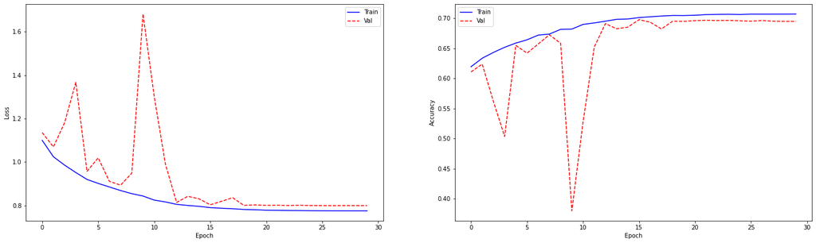

```python
plot_metrics(nn_model_history)
```

```python
if notifyStatus: status_notify('(TensorFlow Multi-Class) Task 3 - Define and Train Models completed on ' + datetime.now().strftime('%A %B %d, %Y %I:%M:%S %p'))
```

# Task 4 - Evaluate and Optimize Models

```python
if notifyStatus: status_notify('(TensorFlow Multi-Class) Task 4 - Evaluate and Optimize Models has begun on ' + datetime.now().strftime('%A %B %d, %Y %I:%M:%S %p'))
```

```python
# Not applicable for this iteration of modeling
```

```python
if notifyStatus: status_notify('(TensorFlow Multi-Class) Task 4 - Evaluate and Optimize Models completed on ' + datetime.now().strftime('%A %B %d, %Y %I:%M:%S %p'))
```

# Task 5 - Finalize Model and Make Predictions

```python
if notifyStatus: status_notify('(TensorFlow Multi-Class) Task 5 - Finalize Model and Make Predictions has begun on ' + datetime.now().strftime('%A %B %d, %Y %I:%M:%S %p'))
```

```python
datagen_kwargs = dict(rescale=1./255)
dataflow_kwargs = dict(batch_size=BATCH_SIZE, class_mode='categorical')

print('Loading and pre-processing the training images...')
training_datagen = ImageDataGenerator(rescale=1./255)
# training_datagen = ImageDataGenerator(rescale=1./255,
#                                       fill_mode="constant",
#                                       shear_range=0.2,
#                                       zoom_range=(0.5, 1),
#                                       horizontal_flip=True,
#                                       vertical_flip=True,
#                                       rotation_range=360,
#                                       width_shift_range=0.2,
#                                       height_shift_range=0.2,
#                                       brightness_range=(0.75, 1.25))
training_generator = training_datagen.flow_from_dataframe(train_dataframe,
                                                          directory=TRAIN_DIR,
                                                          x_col='image_id',
                                                          y_col='label',
                                                          target_size=TARGET_IMAGE_SIZE,
                                                          shuffle=False,
                                                          seed=seedNum,
                                                          **dataflow_kwargs)
print('Number of image batches per epoch of modeling:', len(training_generator))
```

```
Loading and pre-processing the training images...
Found 21397 validated image filenames belonging to 5 classes.
Number of image batches per epoch of modeling: 669
```

```python
# Train the final model with the entire collection of images
FINAL_OPTIMIZER = tf.keras.optimizers.SGD(learning_rate=0.000001)
final_model = create_nn_model(opt_param=FINAL_OPTIMIZER)
final_model.fit(training_generator, epochs=MAX_EPOCH, verbose=1)
print('Total time for model fitting:', (datetime.now() - startTimeModule))
```

```
Total time for model fitting: 4:12:22.638018
```

```python
# Display a summary of the final model
final_model.summary()
```

```
Model: "densenet201"
__________________________________________________________________________________________________
Layer (type)                    Output Shape         Param #     Connected to
==================================================================================================
input_2 (InputLayer)            [(None, 299, 299, 3) 0
__________________________________________________________________________________________________
zero_padding2d_2 (ZeroPadding2D (None, 305, 305, 3)  0           input_2[0][0]
__________________________________________________________________________________________________
conv1/conv (Conv2D)             (None, 150, 150, 64) 9408        zero_padding2d_2[0][0]
__________________________________________________________________________________________________
conv1/bn (BatchNormalization)   (None, 150, 150, 64) 256         conv1/conv[0][0]
__________________________________________________________________________________________________
conv1/relu (Activation)         (None, 150, 150, 64) 0           conv1/bn[0][0]
__________________________________________________________________________________________________
zero_padding2d_3 (ZeroPadding2D (None, 152, 152, 64) 0           conv1/relu[0][0]
__________________________________________________________________________________________________
pool1 (MaxPooling2D)            (None, 75, 75, 64)   0           zero_padding2d_3[0][0]
__________________________________________________________________________________________________
conv2_block1_0_bn (BatchNormali (None, 75, 75, 64)   256         pool1[0][0]
__________________________________________________________________________________________________
conv2_block1_0_relu (Activation (None, 75, 75, 64)   0           conv2_block1_0_bn[0][0]
__________________________________________________________________________________________________
conv2_block1_1_conv (Conv2D)    (None, 75, 75, 128)  8192        conv2_block1_0_relu[0][0]
__________________________________________________________________________________________________
conv2_block1_1_bn (BatchNormali (None, 75, 75, 128)  512         conv2_block1_1_conv[0][0]
__________________________________________________________________________________________________
conv2_block1_1_relu (Activation (None, 75, 75, 128)  0           conv2_block1_1_bn[0][0]
__________________________________________________________________________________________________
conv2_block1_2_conv (Conv2D)    (None, 75, 75, 32)   36864       conv2_block1_1_relu[0][0]
__________________________________________________________________________________________________
conv2_block1_concat (Concatenat (None, 75, 75, 96)   0           pool1[0][0]
                                                                 conv2_block1_2_conv[0][0]
__________________________________________________________________________________________________
conv2_block2_0_bn (BatchNormali (None, 75, 75, 96)   384         conv2_block1_concat[0][0]
__________________________________________________________________________________________________
conv2_block2_0_relu (Activation (None, 75, 75, 96)   0           conv2_block2_0_bn[0][0]
__________________________________________________________________________________________________
conv2_block2_1_conv (Conv2D)    (None, 75, 75, 128)  12288       conv2_block2_0_relu[0][0]
__________________________________________________________________________________________________
conv2_block2_1_bn (BatchNormali (None, 75, 75, 128)  512         conv2_block2_1_conv[0][0]
```

[output cut: 1469 more lines]

```
conv5_block32_concat (Concatena (None, 9, 9, 1920)   0           conv5_block31_concat[0][0]
                                                                 conv5_block32_2_conv[0][0]
__________________________________________________________________________________________________
bn (BatchNormalization)         (None, 9, 9, 1920)   7680        conv5_block32_concat[0][0]
__________________________________________________________________________________________________
relu (Activation)               (None, 9, 9, 1920)   0           bn[0][0]
__________________________________________________________________________________________________
avg_pool (GlobalAveragePooling2 (None, 1920)         0           relu[0][0]
__________________________________________________________________________________________________
predictions (Dense)             (None, 5)            9605        avg_pool[0][0]
==================================================================================================
Total params: 18,331,589
Trainable params: 18,102,533
Non-trainable params: 229,056
__________________________________________________________________________________________________
```

```python
test_dataset_files = os.listdir(TEST_DIR)
test_dataframe = pd.DataFrame({'image_id': test_dataset_files})

# Take a peek at the dataframe after import
print(test_dataframe.head())
```

```
         image_id
0  2216849948.jpg
```

```python
print('Loading and pre-processing the test images...')
test_datagen = ImageDataGenerator(rescale=1./255)
test_generator = test_datagen.flow_from_dataframe(test_dataframe,
                                                  directory=TEST_DIR,
                                                  x_col='image_id',
                                                  target_size=TARGET_IMAGE_SIZE,
                                                  shuffle=False,
                                                  class_mode=None)
print('Number of image batches per epoch of modeling:', len(test_generator))
```

```
Loading and pre-processing the test images...
Found 1 validated image filenames.
Number of image batches per epoch of modeling: 1
```

```python
# Print the labels used for the modeling
print(training_generator.class_indices)
```

```
{'0': 0, '1': 1, '2': 2, '3': 3, '4': 4}
```

```python
# Make batched predictions
test_pred = final_model.predict(test_generator)
test_predictions = np.argmax(test_pred, axis=-1)
# print(test_predictions)
print('The shape of the predictions matrix:', test_predictions.shape)
```

```
The shape of the predictions matrix: (1,)
```

```python
X_kaggle_data = pd.read_csv(LABELS_DIR + SAMPLE_SUBMISSION_CSV)

# Take a peek at the dataframe after import
print(X_kaggle_data.head())
```

```
         image_id  label
0  2216849948.jpg      4
```

```python
X_kaggle_data.drop(X_kaggle_data.index, inplace=True)
X_kaggle_data['image_id'] = test_dataset_files
X_kaggle_data['label'] = test_predictions
print(X_kaggle_data.head())
```

```
         image_id  label
0  2216849948.jpg      3
```

```python
submission_file = X_kaggle_data.to_csv(header=True, index=False)
# filename = 'submission_' + datetime.now().strftime('%Y%m%d-%H%M') + '.csv'
filename = OUTPUT_DIR + FINAL_SUBMISSION_CSV
with open(filename, 'w') as f:
    f.write(submission_file)
    print('Completed writing output file: ' + filename)
```

```
Completed writing output file: staging/submission.csv
```

```python
if notifyStatus: status_notify('(TensorFlow Multi-Class) Task 5 - Finalize Model and Make Predictions completed on ' + datetime.now().strftime('%A %B %d, %Y %I:%M:%S %p'))
```

```python
print ('Total time for the script:',(datetime.now() - startTimeScript))
```

```
Total time for the script: 4:17:53.271493
```